# ESIEE-Paris: 2025 - 2026

Projet 1 : Classification Bayésienne d’Émotions

Ryane SID IDRIS - Yacine OUALIKEN - Sofiane MOUHOUB

22/01/2026

# 1. Introduction

Ce projet vise à classer des textes selon l’émotion qu’ils expriment (Joie, Peur, etc.) en utilisant une approche **Bayésienne Naïve**. Nous utilisons le dataset “Emotion Dataset” de Kaggle.

# 2. Chargement et Exploration des Données

D’abord, nous commençons par charger les librairies nécessaires.

```r
# Chargement des paquets
library(tidyverse)
library(tm)
library(SnowballC)
library(e1071)
library(caret)
library(kableExtra)
```

## 2.1 Importation du Dataset

Nous chargeons le fichier csv.

```r
nom_fichier <- "Emotion_classify_Data.csv"

if(file.exists(nom_fichier)) {
  # Chargement du CSV
  df <- read.csv(nom_fichier, stringsAsFactors = FALSE)

  if(ncol(df) >= 2) {
    colnames(df)[1:2] <- c("text", "emotion")
  }

  # Affichage des premières lignes
  df %>%
    head() %>%
    kbl(caption = "Aperçu des premières lignes") %>%
    kable_styling(bootstrap_options = "striped", full_width = F)

} else {
  stop("erreur")
}
```

Aperçu des premières lignes

| text | emotion |
| --- | --- |
| i seriously hate one subject to death but now i feel reluctant to drop it | fear |
| im so full of life i feel appalled | anger |
| i sit here to write i start to dig out my feelings and i think that i am afraid to accept the possibility that he might not make it | fear |
| ive been really angry with r and i feel like an idiot for trusting him in the first place | joy |
| i feel suspicious if there is no one outside like the rapture has happened or something | fear |
| i feel jealous becasue i wanted that kind of love the true connection between two souls and i wanted that | anger |

## 2.2 Analyse Exploratoire

Visualisation de la répartition des émotions pour vérifier si nos classes sont équilibrées.

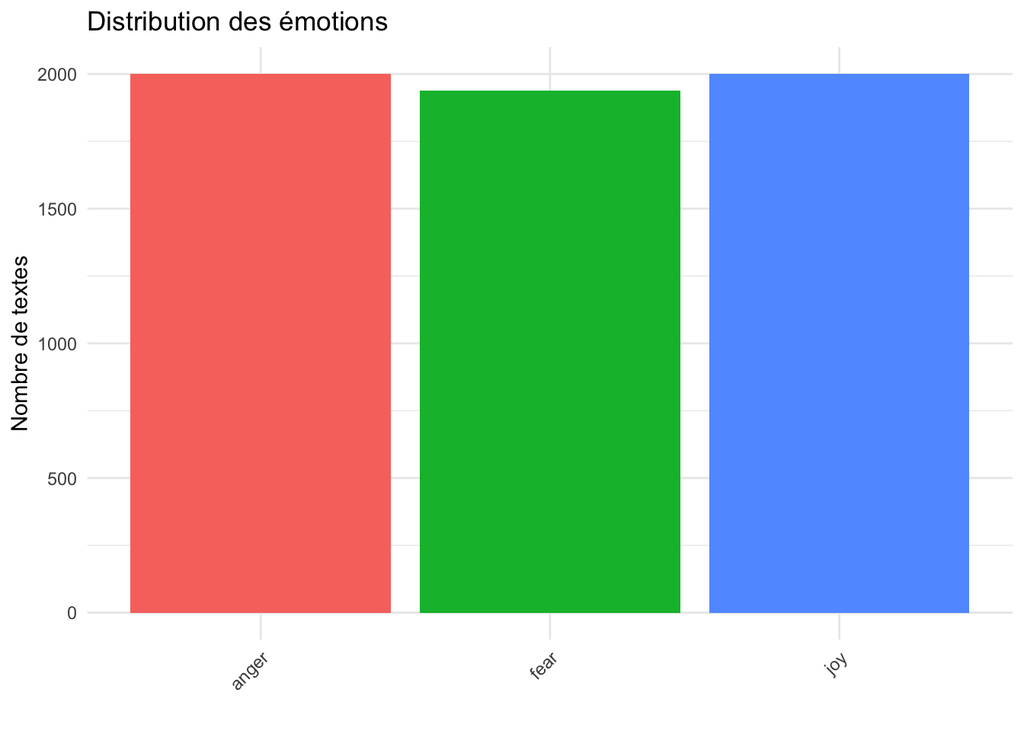

```r
ggplot(df, aes(x = emotion, fill = emotion)) +
  geom_bar() +
  theme_minimal() +
  labs(title = "Distribution des émotions", y = "Nombre de textes", x = "") +
  theme(legend.position = "none", axis.text.x = element_text(angle = 45, hjust = 1))
```

**Analyse du graphique :** Nous observons que le jeu de données est parfaitement équilibré. Les trois classes (colère, peur, joie) contiennent chacune environ 2000 textes. C’est un point positif, car cela évitera que notre modèle ne favorise une émotion par rapport aux autres lors de l’apprentissage.

# 3. Prétraitement des Données (NLP)

Nous nettoyons maintenant les textes (suppression de la ponctuation, des mots vides…) et les transformons en matrice numérique via TF-IDF.

```r
# 1. Création du Corpus
corpus <- VCorpus(VectorSource(df$text))

# 2. Nettoyage
clean_corpus <- function(c) {
  c <- tm_map(c, content_transformer(tolower))
  c <- tm_map(c, removePunctuation)
  c <- tm_map(c, removeNumbers)
  c <- tm_map(c, removeWords, stopwords("en"))
  c <- tm_map(c, stripWhitespace)
  c <- tm_map(c, stemDocument)
  return(c)
}
corpus_clean <- clean_corpus(corpus)

# 3. TF-IDF et Réduction
dtm <- DocumentTermMatrix(corpus_clean, control = list(weighting = weightTfIdf))
# On ne garde que les mots fréquents (99.5%) pour que ça tourne vite
dtm_sparse <- removeSparseTerms(dtm, 0.995)

# 4. Dataframe final
dataset_final <- as.data.frame(as.matrix(dtm_sparse))
dataset_final$target <- as.factor(df$emotion)

cat("Dimensions finales :", dim(dataset_final))
```

```
## Dimensions finales : 5937 366
```

# 4. Modélisation et Résultats

Nous divisons les données (80% apprentissage / 20% test) et lançons l’algorithme **Naive Bayes**.

```r
set.seed(123)

# 1. Division Train / Test
index <- createDataPartition(dataset_final$target, p = 0.8, list = FALSE)
train <- dataset_final[index, ]
test  <- dataset_final[-index, ]

# 2. Entraînement
model <- naiveBayes(target ~ ., data = train, laplace = 1)

# 3. Prédiction sur les 20% restants
pred <- predict(model, test)

# 4. Matrice de confusion et Scores
cm <- confusionMatrix(pred, test$target, mode = "prec_recall")

# Affichage des scores
kbl(cm$byClass[, c("Precision", "Recall", "F1")], caption = "Performance du modèle") %>%
  kable_styling(bootstrap_options = "striped", full_width = F)
```

Performance du modèle

|  | Precision | Recall | F1 |
| --- | --- | --- | --- |
| Class: anger | 0.4623116 | 0.2300000 | 0.3071786 |
| Class: fear | 0.5960265 | 0.2325581 | 0.3345725 |
| Class: joy | 0.3894863 | 0.8150000 | 0.5270816 |

**Interprétation des résultats :** Le tableau ci-dessus nous montre la qualité du modèle pour chaque émotion : * **Precision :** Est-ce que le modèle a raison quand il prédit une émotion ? * **Recall :** Est-ce qu’il n’en oublie pas ? * **F1 :** La note globale (la moyenne des deux).

# 5. Conclusion

**Note personnelle (Ryane SID IDRIS) :** Ce projet a une résonance particulière pour moi. Lors d’un précédent projet de recherche sur un Système de Trading Automatisé, j’avais implémenté des modèles d’analyse de sentiments basés sur **FinBERT** pour prédire les cours de bourse. Il est très intéressant de comparer ces deux approches : le Naive Bayes utilisé ici est beaucoup plus rapide et léger, tandis que les modèles type BERT (utilisés pour le trading) capturent mieux le contexte mais demandent plus de puissance de calcul. Ce projet complète donc ma vision des outils NLP disponibles pour l’analyse de données.